# 4.6 Lab: Logistic Regression, LDA, QDA, and KNN

우선 ISLR 패키지를 불러오도록 한다.

```r
library(ISLR)
```

## 4.6.1 The Stock Market Data

Smarket data는 주식 시장 데이터이며, 2001년부터 2005년까지 총 1,250일 동안의 S&P500 주가지수에 대한 수익률로 구성되어 있다.

|  | Year | Lag1 | Lag2 | Lag3 | Lag4 | Lag5 | Volume | Today | Direction |
| --- | --- | --- | --- | --- | --- | --- | --- | --- | --- |
| 1 | 2001 | 0.381 | -0.192 | -2.624 | -1.055 | 5.010 | 1.1913 | 0.959 | Up |
| 2 | 2001 | 0.959 | 0.381 | -0.192 | -2.624 | -1.055 | 1.2965 | 1.032 | Up |
| 3 | 2001 | 1.032 | 0.959 | 0.381 | -0.192 | -2.624 | 1.4112 | -0.623 | Down |

각 날짜에 대하여 이전 5일 동안의 수익률(Lag1에서 Lag5)이 기록되어 있다. Volume은 이전 날의 주식거래량이며 십억 단위이다. Today는 당일 수익률이다. 마지막으로 Direction은 당일 수익률이 양수인지 음수인지 UP/DOWN으로 나타내며, 결고변수로 활용될 것이다.

```r
names(Smarket)
```

```
[1] "Year"      "Lag1"      "Lag2"      "Lag3"      "Lag4"      "Lag5"      "Volume"    "Today"     "Direction"
```

데이터 세트의 변수명은 names()를 통해서 알 수 있다.

```r
dim(Smarket)
```

```
[1] 1250    9
```

데이터 세트의 행과 열의 개수를 dim()을 통해서 알 수 있다.

```r
summary(Smarket)
```

```
      Year           Lag1                Lag2                Lag3                Lag4
 Min.   :2001   Min.   :-4.922000   Min.   :-4.922000   Min.   :-4.922000   Min.   :-4.922000
 1st Qu.:2002   1st Qu.:-0.639500   1st Qu.:-0.639500   1st Qu.:-0.640000   1st Qu.:-0.640000
 Median :2003   Median : 0.039000   Median : 0.039000   Median : 0.038500   Median : 0.038500
 Mean   :2003   Mean   : 0.003834   Mean   : 0.003919   Mean   : 0.001716   Mean   : 0.001636
 3rd Qu.:2004   3rd Qu.: 0.596750   3rd Qu.: 0.596750   3rd Qu.: 0.596750   3rd Qu.: 0.596750
 Max.   :2005   Max.   : 5.733000   Max.   : 5.733000   Max.   : 5.733000   Max.   : 5.733000
      Lag5              Volume           Today           Direction
 Min.   :-4.92200   Min.   :0.3561   Min.   :-4.922000   Down:602
 1st Qu.:-0.64000   1st Qu.:1.2574   1st Qu.:-0.639500   Up  :648
 Median : 0.03850   Median :1.4229   Median : 0.038500
 Mean   : 0.00561   Mean   :1.4783   Mean   : 0.003138
 3rd Qu.: 0.59700   3rd Qu.:1.6417   3rd Qu.: 0.596750
 Max.   : 5.73300   Max.   :3.1525   Max.   : 5.733000
```

summary()는 데이터 세트의 기본적인 통계량을 알려준다.

```r
cor(Smarket[,-9])
```

```
             Year         Lag1         Lag2         Lag3         Lag4         Lag5      Volume        Today
Year   1.00000000  0.029699649  0.030596422  0.033194581  0.035688718  0.029787995  0.53900647  0.030095229
Lag1   0.02969965  1.000000000 -0.026294328 -0.010803402 -0.002985911 -0.005674606  0.04090991 -0.026155045
Lag2   0.03059642 -0.026294328  1.000000000 -0.025896670 -0.010853533 -0.003557949 -0.04338321 -0.010250033
Lag3   0.03319458 -0.010803402 -0.025896670  1.000000000 -0.024051036 -0.018808338 -0.04182369 -0.002447647
Lag4   0.03568872 -0.002985911 -0.010853533 -0.024051036  1.000000000 -0.027083641 -0.04841425 -0.006899527
Lag5   0.02978799 -0.005674606 -0.003557949 -0.018808338 -0.027083641  1.000000000 -0.02200231 -0.034860083
Volume 0.53900647  0.040909908 -0.043383215 -0.041823686 -0.048414246 -0.022002315  1.00000000  0.014591823
Today  0.03009523 -0.026155045 -0.010250033 -0.002447647 -0.006899527 -0.034860083  0.01459182  1.000000000
```

cor() 함수는 데이터셋의 변수들 간의 상관관계를 행렬로 나타낸다.

여기서 Direction변수의 경우에는 정성데이터이기 때문에 제외하고 계산하였다.

Lag변수와 Today변수간에는 매우 약한 상관관계가 있는 것을 확인할 수 있다. Lag 변수가 당일 전의 수익률을 나타내기 떄문에 전날의 수익률과 오늘의 수익률에는 상관관계가 거의 없는 것으로 보야도 무방하다.

다만, 그나마 Year변수와 Volume변수 간에 유의미한 상관관계가 있는 것을 확인할 수 있다.

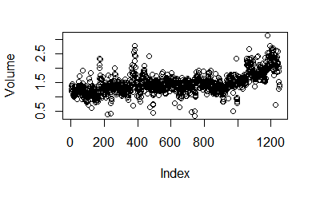

Index가 시간 순서인 점을 감안할 때, 산점도를 통해서 Volume은 시간이 지남에 따라서 증가하는 것을 확인할 수 있다.

즉, 2001년부터 2005년까지 거래량의 평균은 증가하였다고 말할 수 있다.

## 4.6.2 Logistic Regression

이 데이터 세트에 로지스틱 회귀 모델을 적용하여, 예측변수인 Lag와 Volume을 통해서 결과변수인 Direction을 예측할 것이다.

```r
glm.fits =
  glm(Direction ~ Lag1 + Lag2 + Lag3 + Lag4 + Lag5 + Volume,
      family = binomial,
      data = Smarket)
summary(glm.fits)
```

```
Call:
glm(formula = Direction ~ Lag1 + Lag2 + Lag3 + Lag4 + Lag5 +
    Volume, family = binomial, data = Smarket)

Deviance Residuals:
   Min      1Q  Median      3Q     Max
-1.446  -1.203   1.065   1.145   1.326

Coefficients:
             Estimate Std. Error z value Pr(>|z|)
(Intercept) -0.126000   0.240736  -0.523    0.601
Lag1        -0.073074   0.050167  -1.457    0.145
Lag2        -0.042301   0.050086  -0.845    0.398
Lag3         0.011085   0.049939   0.222    0.824
Lag4         0.009359   0.049974   0.187    0.851
Lag5         0.010313   0.049511   0.208    0.835
Volume       0.135441   0.158360   0.855    0.392

(Dispersion parameter for binomial family taken to be 1)

    Null deviance: 1731.2  on 1249  degrees of freedom
Residual deviance: 1727.6  on 1243  degrees of freedom
AIC: 1741.6

Number of Fisher Scoring iterations: 3
```

glm()은 일반선형모형 함수로 로지스틱 회귀 분석 기능을 포함하고 있다. 다만, 로지스틱 회귀를 실행하기 위해서는 family = binomial을 입력해야 한다.  
여기서 가장 작은 유의확률(p-value)은 Lag1에 있다. (p-value 값은 **Pr(>|z|)**에서 알 수 있다.)

이때 Lag1변수의 계수가 음수이기 때문에 이는 익어제 수익을 거두었다면 오늘은 수익을 더 거두기 힘들 것이라는걸 의미한다.

하지만 유의확률(p-value)가 0.145인 것은 유의하다고 보기엔 너무 큰 값이기 때문에 Lag1과 Direction이 유의미한 관계가 있다고만은 볼 수 없다.

```r
coef(glm.fits)
```

```
 (Intercept)         Lag1         Lag2         Lag3         Lag4         Lag5       Volume
-0.126000257 -0.073073746 -0.042301344  0.011085108  0.009358938  0.010313068  0.135440659
```

```r
summary(glm.fits)$coef
```

```
                Estimate Std. Error    z value  Pr(>|z|)
(Intercept) -0.126000257 0.24073574 -0.5233966 0.6006983
Lag1        -0.073073746 0.05016739 -1.4565986 0.1452272
Lag2        -0.042301344 0.05008605 -0.8445733 0.3983491
Lag3         0.011085108 0.04993854  0.2219750 0.8243333
Lag4         0.009358938 0.04997413  0.1872757 0.8514445
Lag5         0.010313068 0.04951146  0.2082966 0.8349974
Volume       0.135440659 0.15835970  0.8552723 0.3924004
```

```r
summary(glm.fits)$coef[,4]
```

```
(Intercept)        Lag1        Lag2        Lag3        Lag4        Lag5      Volume
  0.6006983   0.1452272   0.3983491   0.8243333   0.8514445   0.8349974   0.3924004
```

훈련된 모델의 계수를 알기 위해서는 coef()를 사용하면 된다.

summary()를 통해서도 계수를 확인할 수 있다.

```r
glm.probs = predict(glm.fits, type="response")
glm.probs[1:10]
```

```
        1         2         3         4         5         6         7         8         9        10
0.5070841 0.4814679 0.4811388 0.5152224 0.5107812 0.5069565 0.4926509 0.5092292 0.5176135 0.4888378
```

```r
contrasts(Direction)
```

```
     Up
Down  0
Up    1
```

predict()는 예측변수의 값이 주어졌을 때 당일 수익률이 양수가 될지의 확률을 예측해준다.

**type = “response”**인자는 R에게 로짓(logit)과 같은 정보가 아닌 P(Y=1|X) 형태의 확률을 출력하라고 명령한다. 이는 다른 데이터 세트가 훈련되기 전까지 해당 확률을 유지하게 된다.

contrast()는 당일 수익률 변동을 더미변수로 만들었다는 것을 보여준다. 이를 통해서 UP = 1임을 알 수 있다.

```r
glm.pred = rep("Down", 1250)
glm.pred[glm.probs > .5] = "Up"
```

rep()은 반복하고자 하는 데이터를 지정된 횟수만큼 만들어 벡터로 반환한다. 그리고 glm.probs의 확률 중 50%를 넘는 경우를 T/F로 마스킹하여 같은 위치에 해당하는 glm.pred의 데이터를 “UP”으로 변경하였다.

```r
table(glm.pred, Direction)
```

```
        Direction
glm.pred Down  Up
    Down  145 141
    Up    457 507
```

```r
(507+145)/1250
```

```
[1] 0.5216
```

```r
mean(glm.pred == Direction)
```

```
[1] 0.5216
```

이 모형은 맞출 확률이 50%를 조금 넘기기 떄문에 개인이 임의로 찍는 것보다 조금 더 좋게 예측을 해주는 것으로 보인다.

하지만 이 결과는 잘못되었다. 왜냐하면 이 모델은 똑같은 한 세트 안에 있는 같은 데이터 1250개를 가지고 훈련을 하고 또 테스트를 했기 때문이다. 따라서 이 경우에는 1 - 0.522 = 0.478, 47.8%의 training error rate가 있다고 보면 된다.

로지스틱 회귀 모델의 정확도를 더 잘 측정하기 위해서는 데이터 세트의 일부를 훈련시키고 남은 부분은 모델이 예측을 얼마나 정확하게 하는지 검사하는 용도로 쓰면 된다.

이런 과정을 통해서 오차율을 구하는 것이 더 현실적이다. 왜냐하면 새로운 데이터에 대하여 얼마나 더 예측을 잘 할 것인가에 관심이 있기 떄문이다.

이 과정을 실행하기 위해서 일단 2001 ~ 2004년까지의 관측치를 가지고 있는 벡터를 따로 만들어야 한다.

아래는 위와 동일한 과정이되 다만 훈련세트와 테스트세트를 나누어서 진행한 것이다.

```r
train = (Year<2005)
Smarket.2005 = Smarket[!train, ]
dim(Smarket.2005)
```

```
[1] 252   9
```

```r
Direction.2005 = Direction[!train]
```

```r
glm.fits=glm(Direction ~ Lag1 + Lag2 + Lag3 + Lag4 + Lag5 + Volume,
             data = Smarket,
             family = binomial,
             subset = train)
glm.probs = predict(glm.fits,
                    Smarket.2005,
                    type = "response")
```

glm 내의 subset 인자를 통해서 훈련데이터만을 적용하였다. predict()에선 훈련세트를 통해서 생성된 로지스틱회귀 모델로 테스트세트의 Direction을 예측한다.

```r
glm.pred = rep("Down", 252)
glm.pred[glm.probs > 0.5] = "Up"
table(glm.pred, Direction.2005)
```

```
        Direction.2005
glm.pred Down Up
    Down   77 97
    Up     34 44
```

```r
mean(glm.pred == Direction.2005)
```

```
[1] 0.4801587
```

```r
mean(glm.pred != Direction.2005)
```

```
[1] 0.5198413
```

충격적이게도 이 모델은 임의로 찍는 것보다도 성능이 좋지 않게 나왔따. 여기서 테스트세트의 에러율은 약 52%이기 떄문이다. 근데 사람들이 단순히 이전 날의 수익율만을 보고 주식을 사지는 않는다는 점을 생각할 때 그렇게 충격적인건 또 아니다.

이번에는 그럼 별로 도움이 되지 않아보이는 예측변수들을 제하고 모델을 만들어보자. 아까 예측변수들의 p-value를 구한 표를 참고해서 사용할 변수들만 모아보자.

```r
glm.fits = glm(Direction ~ Lag1 + Lag2,
               data = Smarket,
               family = binomial,
               subset = train)
glm.probs = predict(glm.fits,
                    Smarket.2005,
                    type = "response")
glm.pred = rep("Down", 252)
glm.pred[glm.probs > 0.5] = "Up"
table(glm.pred, Direction.2005)
```

```
        Direction.2005
glm.pred Down  Up
    Down   35  35
    Up     76 106
```

```r
mean(glm.pred == Direction.2005)
```

```
[1] 0.5595238
```

```r
106/(106+76)
```

```
[1] 0.5824176
```

특정 변수만 투입을 한 결과 정확도는 56%로 이전 결과보다 조금 더 좋아졌다. 그래도 에러율을 보았을 때 임의로 선택하는 방법보다 아주 나은 것은 아니다. 하지만 confusion matrix에서 모델이 시장의 증가를 예측하는 날에는 58%의 정확도를 보여준다.

```r
predict(glm.fits,
        newdata = data.frame(Lag1 = c(1.2, 1.5),
                             Lag2 = c(1.1, -0.8)),
        type = "response")
```

```
        1         2
0.4791462 0.4960939
```

특정한 날의 값을 예측하고 싶을 떄에는 다음과 같이 코드를 작성하면 됩니다.